# Statistical and Theoretical Reductionism in Research on Scientific Thinking

## Scientific Thinking in Children

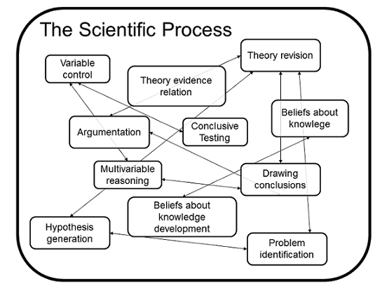

## Scientific Thinking

- Long interest in education, development, **assessment** (Blair, 1940; Piaget & Inhelder, 1958).
- Two waves of test development (Opitz, Fischer, & Heene, submitted)
  - wave I: 1970-1990.
  - wave II: since 2000s. Following PISA etc. **Rasch Application.**

## Research Questions

1. Practices in the **application** of the Rasch Model.
2. Practices in the **interpretation** of the Rasch Model.

## The Rasch Model

\(p(x_{pi})=\frac{exp(x_{pi}(\theta_p-\sigma_i))}{{1+exp(\theta_p-\sigma_i)}}\)

person ability \(\theta_p\), item difficulty \(\sigma_i\)

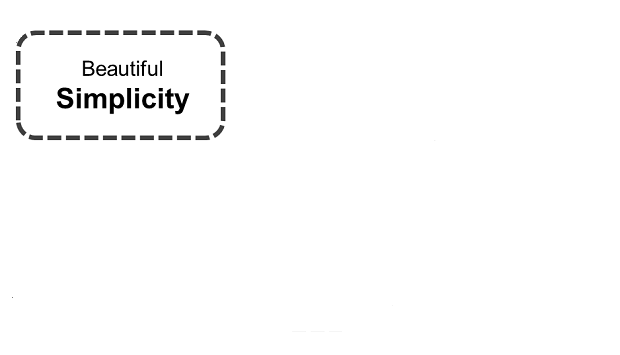

## The Rasch Model

\(p(x_{pi})=\frac{exp(x_{pi}(\theta_p-\sigma_i))}{{1+exp(\theta_p-\sigma_i)}}\)

person ability \(\theta_p\), item difficulty \(\sigma_i\)

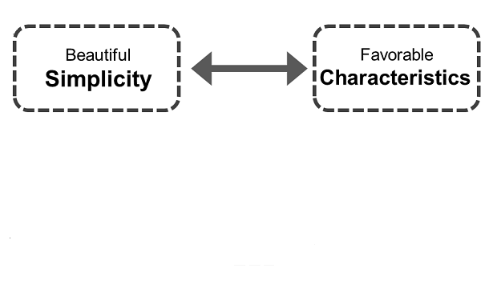

## The Rasch Model

\(p(x_{pi})=\frac{exp(x_{pi}(\theta_p-\sigma_i))}{{1+exp(\theta_p-\sigma_i)}}\)

person ability \(\theta_p\), item difficulty \(\sigma_i\)

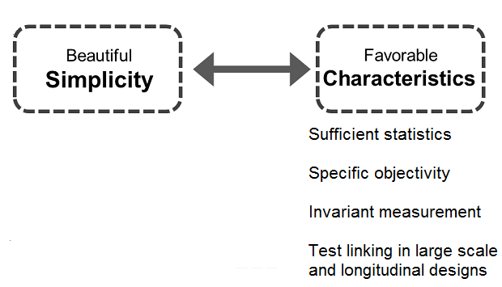

## The Rasch Model

\(p(x_{pi})=\frac{exp(x_{pi}(\theta_p-\sigma_i))}{{1+exp(\theta_p-\sigma_i)}}\)

person ability \(\theta_p\), item difficulty \(\sigma_i\)

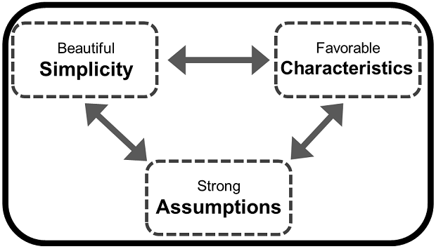

## The Rasch Model: Strong Assumptions

- Unidimensionality
  - One coherent psychological trait
- Local (stochastic) independence
  - No additional systematic influences on answers
- Homogenous item discriminations
  - Parallel Item Characteristic Curves (equal factor loadings)

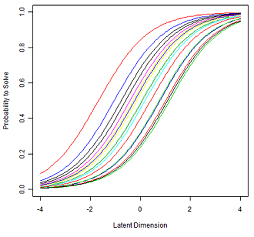

## Practices in the Field: Rasch **Application**

| Reference | Infit | Criterion | Software |
| --- | --- | --- | --- |
| Mayer at al. (2014) | x | - | ConQuest |
| Koerber et al. (2014) | x | 0.85-1.15 (-) | ConQuest |
| Hartmann et al. (2015) | x | - | ConQuest |
| Nowak et al. (2013) | x | 0.8-1.2 (Adams, 2002) | ConQuest |
| Grube (2010) | x | 0.8-1.2 (Adams, 2000) | ConQuest |
| Heene (2007) | x | 0.8-1.2 (Wright, 2000) | ConQuest, WS, FC, WM |
| Brown et al. (2010) | x | - | ConQuest |

## Itemfit

- Based on the individual response residuals

  \[ \begin{align} R_{pi} &= X_{pi} - E_{pi}\\ Z_{pi}^2 &= \frac{R_{pi}^2}{VAR(X_{pi})}\\ \end{align} \]
- \[ \begin{equation} INFIT_i = \frac{\sum^n_{p=1}R^2_{pi}}{\sum^n_{p=1}VAR(X_{pi})} \end{equation} \]
- Degree of item-level deviation from expected scores given the Rasch model

## Itemfit

- Adequacy for model fit testing **strongly criticized** (Christensen & Kreiner, 2013; Heene et al., 2014; Smith, 1995; Smith, 1996; Smith et al., 1998)
  - Underpowered.
  - Should be applied only after investigation of **global model fit**.
  - Item removal might **reduce construct validity**.
- **Item infit statistics are inadequate to evaluate the fit of the Rasch model.**

## Itemfit: Simulations

- Dichotomous data
  - used R package eRm
  - Item size: 12, 24, 60, 120
  - Sample Size: 150, 300, 500, 1000
  - 1000 data sets per combination
  - Code, slides, comments at https://github.com/dostodabsi/simrasch

## Simulation I

- unequal item discrimination
- \(d_i \sim \text{lognormal}(0, \sigma)\)
- \(\sigma\) either .1, .3, .5

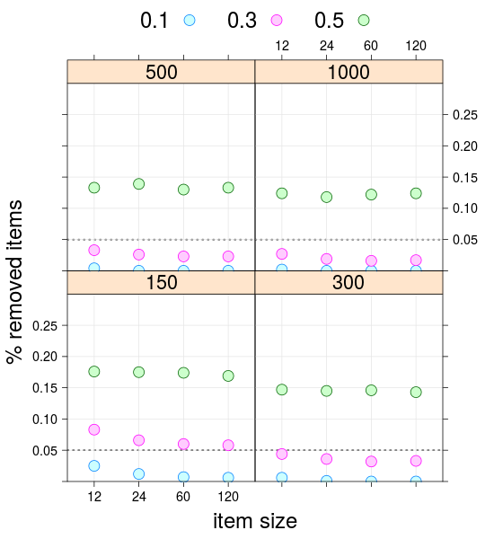

## Simulation I

- Results:
  - Note that **we did not test the Rasch model**
  - We assumed that it holds and threw out certain items
- Question:
  - After removal of "bad" items, does the Rasch model hold?
  - Not tested in the literature - let's simulate it!

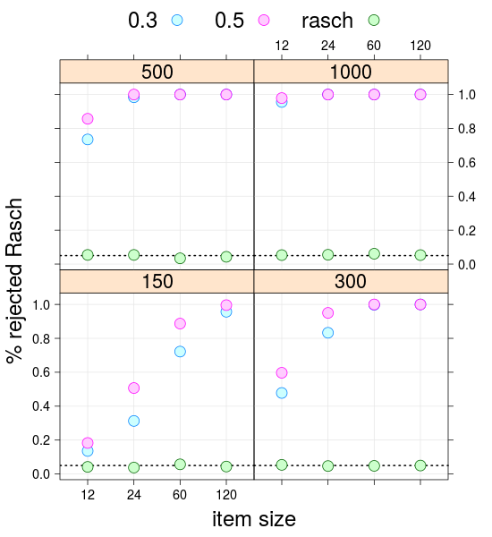

## Simulation II

- Typical theoretical model
  - 3-5 correlated facets of Scientific Reasoning assumed
  - Simulated factor structure:
  - \(\left( \begin{array}{ccc} 1.0 & 0.6 & 0.5 & 0.4\\ 0.6 & 1.0 & 0.7 & 0.4\\ 0.5 & 0.7 & 1.0 & 0.3\\ 0.4 & 0.4 & 0.3 & 1.0 \end{array} \right)\)
  - How do infit statistics respond to such data?

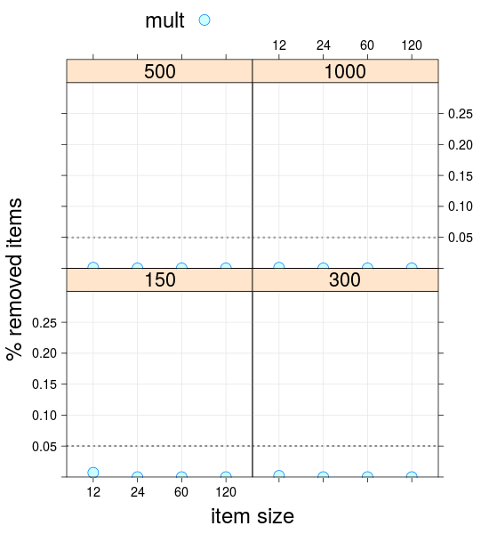

## Simulation II

- Results:
  - item fit statistics **completely miss the point**
  - very few items "have to be removed"
  - Unidimensional Rasch model shows low reliability (about .5 - .6)
- Conclusion:
  - **Simulated scenario yields results similar to reviewed articles**
  - **Might the simulated scenario reflect what is happening in the field?**

## Practices in the Field: **Interpretation**

| Reference | Theoretical models | Fitted models | Best fit | Reliability | Itemfit |
| --- | --- | --- | --- | --- | --- |
| Mayer at al. (2014) | 4D | 1D | na | 1D | 1D |
| Koerber et al. (2014) | 1D, 5D | 1D | na | 1D | 1D |
| Hartmann et al. (2015) | 1D | 1D | na | 1D | 1D |
| Nowak et al. (2013) | 1D, 3D | 1D, 3D | 3D | 1D | 1D |
| Grube (2010) | 4D | 1D, 4D | 4D | 1D | 1D |
| Heene (2007) | 1D | 1D | na | 1D | 1D |
| Brown et al. (2010) | 1D | 1D | na | 1D | 1D |

## Practices in the Field: **Interpretation**

- Conclusions in reviewed articles:
  - "scale measures unitary construct, support for unidimensional theoretical model"
- Our conclusions:
  - **Theoretical models, modeling practices, and theoretical conclusions are inconsistent.**
  - **Researchers engage in tautological and reductionist reasoning that supports their theoretical models and instrument quality.**

## Discussion

- Two traditional **perspectives on Rasch**: Utility vs. hypothesis testing (cf. Linacre, 2010).
- Researchers apply practices of the *utility school*. **Potential reasons?**
  - Following large scale programs
  - Limiting software (ConQuest)
  - Lack of knowledge about alternative model tests

## Suggestions

- **Acknowledge the hypothesis testing perspective**
  - Andersen test (Andersen, 1973)
  - Martin Löf test (Christensen et al., 2002)
  - Recursive Partitioning (Strobl et al., 2013)
  - M2 statistic (Maydeu-Olivares, 2013)
  - nonparametric statistics (Koller et al., 2015)
  - posterior predictive checking (Fox, 2010; Sinharay, 2006)
  - SEM-like statistics (Maydeu-Olivares, 2014)

## Suggestions

- **Match theoretical and statistical models**
  - IRT: Multidimensional Rasch, 2PL, mixture models (Fischer & Molenaar, 1995)
  - Nonparametric IRT: mokken scaling (van der Graaf et al., 2015)
  - Applied IRT: cognitive diagnosis models (de la Torre & Minchen, 2014)

## Suggestions

[figure not shown]

## Suggestions

- **Acknowledge complexity**
  - Network models (Schmittman et al., 2013)
  - Longitudinal and experimental designs to examine interactions

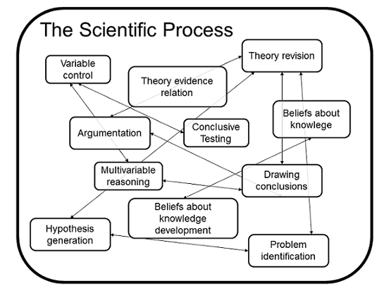

## Thanks!

https://github.com/dostodabsi/simrasch